### The Sound of Gunfire, Off in the Distance

Our first dataset this week comes from a study of the causes of civil wars.[^1] The data can be read into from a csv posted online by using the following command.

```r
war <- read.csv("http://www.stat.cmu.edu/~cshalizi/uADA/15/hw/06/ch.csv", row.names = 1)
```

Every row of the data represents a combination of a country and of a five year interval — the first row is Afghanistan, 1960, really meaning Afghanistan, 1960–1965. The variables are:

- The country name;
- The year;
- An indicator for whether a civil war began during that period: 1 indicates a civil war has begun, the code of NA means an on-going civil war, 0 means peace.
- Exports, really a measure of how dependent the country’s economy is on com- modity exports;
- Secondary school enrollment rate for males, as a percentage;
- Annual growth rate in GDP;
- An index of the geographic concentration of the country’s population (which would be 1 if the entire population lives in one city, and 0 if it evenly spread across the territory);
- The number of months since the country’s last war or the end of World War II, whichever is more recent;
- The natural logarithm of the country’s population;
- An index of social “fractionalization”, which tries to measure how much the country is divided along ethnic and/or religious lines;
- An index of ethnic dominance, which tries to measure how much one ethnic group runs affairs in the country.

Some of these variables are NA for some countries.

1.) Fit a logistic regression model for the start of civil war on all other variables except country and year (yes, this makes some questionable assumptions about independent observations); include a quadratic term for exports. Report the coefficients and their standard errors, together with R’s p-values. Which ones are found to be significant at the 5% level?

There are a number of missing values among the predictor/response variables in the dataset. I don’t know much about imputation, so for this exercise I’ll be dropping all records of data that have at least one missing value.

```r
#removing records with missing values in the predictor/response variables
war_complete <-
  war[which(!is.na(war$exports) & !is.na(war$schooling) &
              !is.na(war$growth) & !is.na(war$peace) & !is.na(war$concentration) &
              !is.na(war$lnpop) & !is.na(war$fractionalization) & !is.na(war$dominance) & !is.na(war$start)), ]
row.names(war_complete) <- 1:nrow(war_complete)
war_complete$exports.squared <- war_complete$exports * war_complete$exports
war_model <- glm(data = war_complete, formula = start ~ exports + exports.squared + schooling + growth + peace + concentration + lnpop + fractionalization + dominance, family = binomial)
summary(war_model)
```

```
##
## Call:
## glm(formula = start ~ exports + exports.squared + schooling +
##     growth + peace + concentration + lnpop + fractionalization +
##     dominance, family = binomial, data = war_complete)
##
## Deviance Residuals:
##     Min       1Q   Median       3Q      Max
## -1.3655  -0.3627  -0.1893  -0.0932   3.3636
##
## Coefficients:
##                     Estimate Std. Error z value Pr(>|z|)
## (Intercept)       -1.307e+01  2.795e+00  -4.677 2.91e-06 ***
## exports            1.894e+01  5.865e+00   3.229 0.001243 **
## exports.squared   -2.944e+01  1.178e+01  -2.499 0.012449 *
## schooling         -3.156e-02  9.784e-03  -3.225 0.001259 **
## growth            -1.152e-01  4.307e-02  -2.675 0.007466 **
## peace             -3.713e-03  1.093e-03  -3.397 0.000681 ***
## concentration     -2.487e+00  1.005e+00  -2.474 0.013357 *
## lnpop              7.677e-01  1.658e-01   4.632 3.63e-06 ***
## fractionalization -2.135e-04  9.102e-05  -2.345 0.019020 *
## dominance          6.704e-01  3.535e-01   1.896 0.057920 .
## ---
## Signif. codes:  0 '***' 0.001 '**' 0.01 '*' 0.05 '.' 0.1 ' ' 1
##
## (Dispersion parameter for binomial family taken to be 1)
##
##     Null deviance: 337.73  on 687  degrees of freedom
## Residual deviance: 256.42  on 678  degrees of freedom
## AIC: 276.42
##
## Number of Fisher Scoring iterations: 7
```

All variables used in the model as predictors, except for dominance, are significant at the 5% level.

2.1) What is the model’s predicted probability for a civil war in India in the period beginning 1975? What probability would it predict for a country just like India in 1975, except that its male secondary school enrollment rate was 30 points higher? What probability would it predict for a country just like India in 1975, except that the ratio of commodity exports to GDP was 0.1 higher?

The Indian data for 1975 is on the 272nd row of the complete war data, so I’ll use the predict.glm() function with the fitted model on the 272nd row of the war data and specify a “response” type so that a probability is outputted.

```r
India.1975.War.Prob <- predict.glm(war_model, newdata = war_complete[272, ], type = "response")
print(India.1975.War.Prob)
```

```
##       272
## 0.3504199
```

The model predicts about a 35% chance of civil war beginning in India in 1975.

```r
India.1975.Higher.Schooling <- war_complete[272, ]
India.1975.Higher.Schooling$schooling <- India.1975.Higher.Schooling$schooling + 30
India.1975.Higher.Schooling.War.Prob <- predict.glm(war_model, newdata = India.1975.Higher.Schooling, type = "response")
print(India.1975.Higher.Schooling.War.Prob)
```

```
##     272
## 0.17309
```

Increasing the male secondary schooling percentage by 30 points decreases the probability of civil war by about 18% to about 17%. I’m not a sociologist, but this result makes some intuitive sense. I’d expect (or at least hope), that a more educated country is less likely to go to war with itself.

To address the second hypothetical country, I first need to calculate the ratio of exports to GDP to determine what adjustments I need to make to raise the ratio by .1 points.

```r
India.1975.Higher.Exports <- war_complete[272, ]
India.1975.ratio <- India.1975.Higher.Exports$exports / India.1975.Higher.Exports$growth
print(India.1975.ratio)
```

```
## [1] 0.08074534
```

The new ratio needs to be 0.18074534. With a little bit of algebra…

```r
India.1975.new.exports <- (India.1975.ratio + .1) * India.1975.Higher.Exports$growth
print(India.1975.new.exports)
```

```
## [1] 0.0582
```

```r
India.1975.ratio_check <- India.1975.new.exports / India.1975.Higher.Exports$growth
print(India.1975.ratio_check)
```

```
## [1] 0.1807453
```

The adjusted value for exports is .0582.

```r
India.1975.Higher.Exports$exports <- .0582
India.1975.Higher.Exports.War.Prob <- predict.glm(war_model, newdata = India.1975.Higher.Exports, type = "response")
print(India.1975.Higher.Exports.War.Prob)
```

```
##       272
## 0.4981447
```

The probability for civil war with this hypothetical country with a .1 greater ratio of exports to GDP growth is about 50%, which is about a 15% increase over the baseline India 1975 data.

2.2) What is the model’s predicted probability for a civil war in Nigeria in the period beginning 1965? What probability would it predict for a country just like Nigeria in 1965, except that its male secondary school enrollment rate was 30 points higher? What probability would it predict for a country just like Nigeria in 1965, except that the ratio of commodity exports to GDP was 0.1 higher?

The 1965 Nigerian data is on row 464 of the complete war data.

```r
Nigeria.1965.War.Prob <- predict.glm(war_model, newdata = war_complete[464, ], type = "response")
print(Nigeria.1965.War.Prob)
```

```
##       464
## 0.1709917
```

The probability of civil war in Nigeria in 1965 is about 17%.

```r
Nigeria.1965.Higher.Schooling <- war_complete[464, ]
Nigeria.1965.Higher.Schooling$schooling <- Nigeria.1965.Higher.Schooling$schooling + 30
Nigeria.1965.Higher.Schooling.War.Prob <- predict.glm(war_model, newdata = Nigeria.1965.Higher.Schooling, type = "response")
print(Nigeria.1965.Higher.Schooling.War.Prob)
```

```
##        464
## 0.07410315
```

The civil war probability of this hypothetical country with higher education levels is about 7%, which is about a 10% decrease from the baseline Nigeria 1965 data.

To address the next hypothetical country, I first need to calculate the ratio of exports to GDP to determine what adjustments I need to make to raise the ratio by .1 points.

```r
Nigeria.1965.Higher.Exports <- war_complete[464, ]
Nigeria.1965.ratio <- Nigeria.1965.Higher.Exports$exports / Nigeria.1965.Higher.Exports$growth
print(Nigeria.1965.ratio)
```

```
## [1] 0.06419624
```

The new ratio needs to be 0.16419624. With a little bit of algebra…

```r
Nigeria.1965.new.exports <- (Nigeria.1965.ratio + .1) * Nigeria.1965.Higher.Exports$growth
print(Nigeria.1965.new.exports)
```

```
## [1] 0.3146
```

```r
Nigeria.1965.ratio_check <- Nigeria.1965.new.exports / Nigeria.1965.Higher.Exports$growth
print(Nigeria.1965.ratio_check)
```

```
## [1] 0.1641962
```

The adjusted value for exports is .3146.

```r
Nigeria.1965.Higher.Exports$exports <- .3146
Nigeria.1965.Higher.Exports.War.Prob <- predict.glm(war_model, newdata = Nigeria.1965.Higher.Exports, type = "response")
print(Nigeria.1965.Higher.Exports.War.Prob)
```

```
##       464
## 0.8859196
```

The civil war probability for this hypothetical country with higher exports is about 89%, which is about a 72% increase over the baseline 1965 Nigeria data.

2.3) In the parts above, you changed the same predictor variables by the same amounts. If you did your calculations properly, the changes in predicted probabilities are not equal. Explain why not. (The reasons may or may not be the same for the two variables.)

```r
print(India.1975.Higher.Schooling.War.Prob - India.1975.War.Prob)
```

```
##        272
## -0.1773298
```

```r
print(Nigeria.1965.Higher.Schooling.War.Prob - Nigeria.1965.War.Prob)
```

```
##         464
## -0.09688857
```

```r
print(India.1975.Higher.Exports.War.Prob - India.1975.War.Prob)
```

```
##       272
## 0.1477248
```

```r
print(Nigeria.1965.Higher.Exports.War.Prob - Nigeria.1965.War.Prob)
```

```
##       464
## 0.7149279
```

```r
war_complete[272, ]
```

```
##     country year start exports schooling growth peace concentration
## 272   India 1975     0   0.026        36  0.322   112         0.537
##        lnpop fractionalization dominance exports.squared
## 272 20.23462              2937         0        0.000676
```

```r
war_complete[464, ]
```

```
##     country year start exports schooling growth peace concentration
## 464 Nigeria 1965     1   0.123         7  1.916   232         0.539
##        lnpop fractionalization dominance exports.squared
## 464 17.65479              6090         0        0.015129
```

The classic interpretation for a logistic regression coefficient is along the lines of: “assuming all else is equal, a 1 unit change in predictor variable x corresponds to a y increase in the log odds of the response variable being equal to 1”. While in this case we are making similar changes to predictor variables in these two examples, the assumption that all else is equal does not hold up. Thus, the differences in the other predictor variables between India 1975 and Nigeria 1965 that are being fed into the model account for the different changes in predicted war probabilities.

3.1) Build a 2 × 2 *confusion matrix* (a.k.a. “classification table” or “contigency table”) which counts: the number of outbreaks of civil war correctly predicted by the logistic regression; the number of civil wars not predicted by the model; the number of false predictions of civil wars; and the number of correctly predicted absences of civil wars. (Note that some entries in the table may be zero.)

First, I’ll make predictions using the fitted model across the entire dataset, using .5 as a cutoff. Then, I’ll make the confusion matrix using the table() function.

```r
war_complete$predicted.start.prob <- predict.glm(war_model, newdata = war_complete, type = "response")
war_complete$predicted.start <- ifelse(war_complete$predicted.start.prob >= .5, 1, 0)
confusion.matrix <- table(war_complete$start, war_complete$predicted.start, dnn = c("Actual Wars", "Predicted Wars"))
print(confusion.matrix)
```

```
##            Predicted Wars
## Actual Wars   0   1
##           0 637   5
##           1  43   3
```

3.2) What fraction of the logistic regression’s predictions are incorrect, i.e. what is the misclassification rate? (Note that this is if anything too kind to the model, since it’s looking at predictions to the same training data set).

```r
misclassification.rate <- 1 - (((confusion.matrix[1] + confusion.matrix[4])) / sum(confusion.matrix))
print(misclassification.rate)
```

```
## [1] 0.06976744
```

The misclassification rate is about 7%.

3.3) Consider a foolish (?) pundit who always predicts “no war”. What fraction of the pundit’s predictions are correct on the whole data set? What fraction are correct on data points where the logistic regression model also makes a prediction?

The pacifist pundit’s accuracy across the whole data set can be found by calculating the percentage of zeros in the ‘start’ column of the data vs. the total number of non-missing values in the ‘start’ column.

```r
pacifist.accuracy.vs.whole <- sum(war$start == 0 & !is.na(war$start)) / sum((war$start == 0 | war$start == 1) & !is.na(war$start))
print(pacifist.accuracy.vs.whole)
```

```
## [1] 0.933162
```

The pacifist pundit’s accuracy across the data points where the logistic regression model also makes a prediction can be found by calculating the percentage of zeros in the ‘predicted.zeros’ column of the complete data vs. the total number of values in the ‘predicted.zeros’ column.

```r
pacifist.accuracy.vs.predicted <- sum(war_complete$predicted.start == 0) / sum(war_complete$predicted.start == 0 | war_complete$predicted.start == 1)
print(pacifist.accuracy.vs.predicted)
```

```
## [1] 0.9883721
```

4.1) Fit an Linear Discriminant Analysis (LDA) model using the same predictors that you used for your logistic regression model. What is the training misclassification rate?

```r
library(MASS) # used for LDA and QDA

war_lda_model <-
  lda(formula = start ~ exports + exports.squared + schooling + growth + peace + concentration + lnpop + fractionalization + dominance, data = war_complete, CV = TRUE, na.action = "na.omit")
war_complete$predicted.start.lda <- war_lda_model$class
war_complete$predicted.start.lda <- as.numeric(levels(war_complete$predicted.start.lda))[war_complete$predicted.start.lda]
confusion.matrix.lda <- table(war_complete$start, war_complete$predicted.start.lda, dnn = c("Actual Wars", "Predicted Wars"))
print(confusion.matrix.lda)
```

```
##            Predicted Wars
## Actual Wars   0   1
##           0 635   7
##           1  42   4
```

```r
misclassification.rate.lda <- 1 - (((confusion.matrix.lda[1] + confusion.matrix.lda[4])) / sum(confusion.matrix.lda))
print(misclassification.rate.lda)
```

```
## [1] 0.07122093
```

The misclassification rate for the LDA model is about 7%.

4.2) Fit a Quadratic Discriminat Analysis (QDA) model using the very same predictors. What is the training misclassification rate?

```r
war_qda_model <- qda(formula = start ~ exports + exports.squared + schooling + growth + peace + concentration + lnpop + fractionalization + dominance, data = war_complete, CV = TRUE, na.action = "na.omit")
war_complete$predicted.start.qda <- war_qda_model$class
war_complete$predicted.start.qda <- as.numeric(levels(war_complete$predicted.start.qda))[war_complete$predicted.start.qda] # converting factor to numeric
confusion.matrix.qda <- table(war_complete$start, war_complete$predicted.start.qda, dnn = c("Actual Wars", "Predicted Wars"))
print(confusion.matrix.qda)
```

```
##            Predicted Wars
## Actual Wars   0   1
##           0 615  27
##           1  33  13
```

```r
misclassification.rate.qda <- 1 - (((confusion.matrix.qda[1] + confusion.matrix.qda[4])) / sum(confusion.matrix.qda))
print(misclassification.rate.qda)
```

```
## [1] 0.0872093
```

4.3) How does the prediction accuracy of the three models compare? Why do you think this is?

```r
print(1 - misclassification.rate)
```

```
## [1] 0.9302326
```

```r
print(1 - misclassification.rate.lda)
```

```
## [1] 0.9287791
```

```r
print(1 - misclassification.rate.qda)
```

```
## [1] 0.9127907
```

The prediction accuracy of the three models are relatively close; there’s less than a 2% difference between the best and worst performing models. The logistic model performed best in terms of accuracy. I’d guess that the logistic model performed best, albeit slightly, because the assumptions for logistic regression are more relaxed compared to LDA and QDA. Namely, LDA and QDA assumes that the predictor variables are normally distributed within each class of the response variable. Below is a side by side box-plot of examining the distribution of the fractionalization predictor between warring and non-warring countries. In both cases, the distribution is not normal; therefore the normality assumption of LDA and QDA is violated.

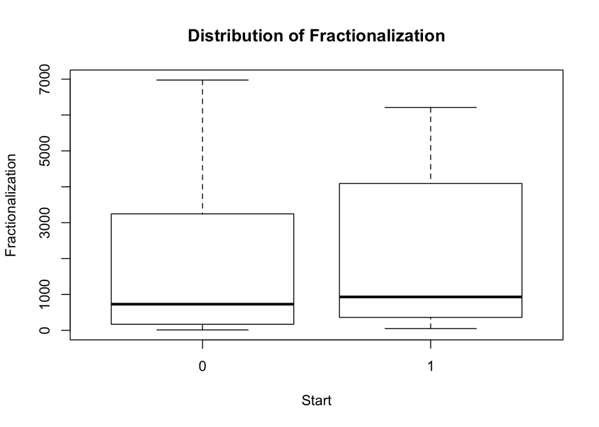

```r
boxplot(war_complete$fractionalization ~ war_complete$start, main = "Distribution of Fractionalization", xlab = "Start", ylab = "Fractionalization")
```

5.) Construct an ROC curve for all three of your models. Plot the ROC curves of all three models on the same plot.

I’m using the ROCR package, based off of Nate’s example under week 2 in the “bangladesh-wells-logistic-example.R”. To be honest I’m not sure this plot is correct as it doesn’t look like what I’d expect. I’ve also included the AUC values for the logistic, LDA, and QDA models respectively.

```r
library(ROCR)
```

```r
pred <- perf <-  vector("list", 3)
pred[[1]] <- prediction(war_complete$predicted.start, war_complete$start)
pred[[2]] <- prediction(war_complete$predicted.start.lda, war_complete$start)
pred[[3]] <- prediction(war_complete$predicted.start.qda, war_complete$start)
perf[[1]] <- performance(pred[[1]], measure = "tpr", x.measure = "fpr")
perf[[2]] <- performance(pred[[2]], measure = "tpr", x.measure = "fpr")
perf[[3]] <- performance(pred[[3]], measure = "tpr", x.measure = "fpr")
for (i in 1:3) print(performance(pred[[i]], measure="auc")@y.values[[1]]) ## Area under curve
```

```
## [1] 0.5287146
## [1] 0.5380265
## [1] 0.6202763
```

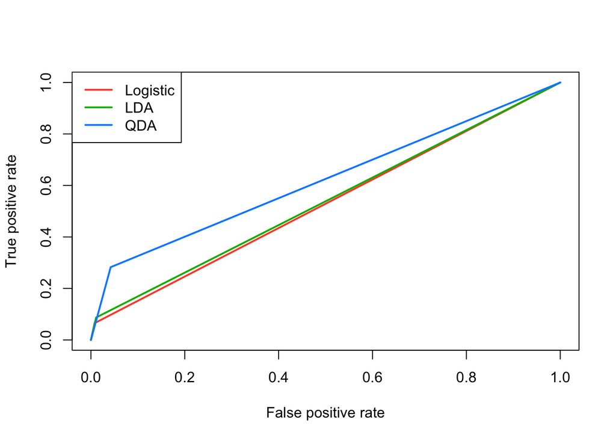

```r
col <- c("#FF4E37FF", "#00B500FF", "#008DFFFF")
plot(perf[[1]], lwd=2, col=col[1])
plot(perf[[2]], add=TRUE, col=col[2], lwd=2)
plot(perf[[3]], add=TRUE, col=col[3], lwd=2)
legend("topleft", col=col, legend=c("Logistic", "LDA", "QDA" ), lwd=2)
```

6.) Fit a logistic regression using `y` as the response with `x1` and `x2` as indepedent variables. Does anything strange happen? Explain.

```r
y<- c(0,0,0,0,1,1,1,1)
x1<-c(1,2,3,3,5,6,10,11)
x2<-c(3,2,-1,-1,2,4,1,0)

fit <- glm(y ~ x1 + x2, family = binomial)
```

```
## Warning: glm.fit: fitted probabilities numerically 0 or 1 occurred
```

```r
summary(fit)
```

```
##
## Call:
## glm(formula = y ~ x1 + x2, family = binomial)
##
## Deviance Residuals:
##          1           2           3           4           5           6
## -2.110e-08  -1.404e-05  -2.522e-06  -2.522e-06   1.564e-05   2.110e-08
##          7           8
##  2.110e-08   2.110e-08
##
## Coefficients:
##               Estimate Std. Error z value Pr(>|z|)
## (Intercept)    -66.098 183471.722   0.000        1
## x1              15.288  27362.843   0.001        1
## x2               6.241  81543.720   0.000        1
##
## (Dispersion parameter for binomial family taken to be 1)
##
##     Null deviance: 1.1090e+01  on 7  degrees of freedom
## Residual deviance: 4.5454e-10  on 5  degrees of freedom
## AIC: 6
##
## Number of Fisher Scoring iterations: 24
```

Trying to fit a logistic model on this data generates a warning. Looking at the summary of the fitted model, the p-values for the intercept and each of the predictor variables are equal to 1. This is happening because there is “complete separation”" in the data. Complete separation occurs when a predictor variable correctly allocates all observations to the response variable. In this data, if x1 <= 3 then y = 0 and if x1 > 3 then y = 1, so y separates x1 perfectly. In other words, we can conclude that Prob(y = 1 | x1 <= 3) = 0 and Prob(y = 1 | x1 > 3) = 1 without constructing a logistic model. When trying to fit a logistic model on this data, R gets confused since mathematically the MLE for x1 doesn’t exist because it’s coefficient is technically infinite.

[^1]: Based on an exercise of Cosmo Shalizi’s that uses data from Collier, Paul and Anke Hoeffler (2004). *Greed and Grievance in Civil War.* Oxford Economic Papers, 56: 563–595. URL: http://economics.ouls.ox.ac.uk/12055/1/2002-01text.pdf.